# Objective B

Slyterin

# 1 Design of the study

## 1.1 Aims

The goal is to investigate Bayesian methods for estimating the geometric mean (GM), geometric standard deviation (GSD), arithmetic mean (AM), and 95% quantile of left-censored real-world data, using both one-element and highly correlated two-element models with multiple reporting limits. These Bayesian approaches will be compared to existing frequentist methods, including substitution and regression on order statistics (ROS).

## 1.2 Estimands

**Single-element model**

Our estimands for single-element model include geometric mean (GM), geometric standard deviation (GSD), arithmetic mean (AM) and 95% quantile (Q95) for the concentration.

**Two-element model**

The estimands for two-element model also include geometric mean, geometric standard deviation, arithmetic mean and 95% quantile but for the sum of the two concentrations.

## 1.3 Methods

Each simulated dataset is analyzed using both Bayesian and Frequentist methods:

- Bayesian methods: Gibbs and Metropolis
- Frequentist: substitution and ROS

## 1.4 Performance measures

**Bayesian model diagnostic**

- Gelman-Rubin $\hat R$
- Effective Sample Size (ESS)
- Autocorrelaiton (ACF)

**Bayesian model predictive checking**

- Visual analysis of the overlapping of the original data and the predictive data

# 2 Exploratory analysis

## 2.1 Single-element

The dataset contains a total of 11,534 rows, with more than 77% of the data being censored. Out of the 8,889 reporting limits, only 61 unique values exist, ranging from $3.000 \times 10^{-10}$ to $8.333 \times 10^{-4}$. The maximum observed value in the data is $2.381 \times 10^{-3}$.

The histogram displays the concentration distribution on a log scale. The observed data are represented by the blue bars (histogram), while the vertical orange lines indicate the censoring at various reporting limits. The darker color of the lines highlights the concentration of censoring around specific concentration levels. From the histogram, we can see that most reporting limits are centered around the mode of the observed values, with a few very high reporting limits extending into the right tail of the observed data.

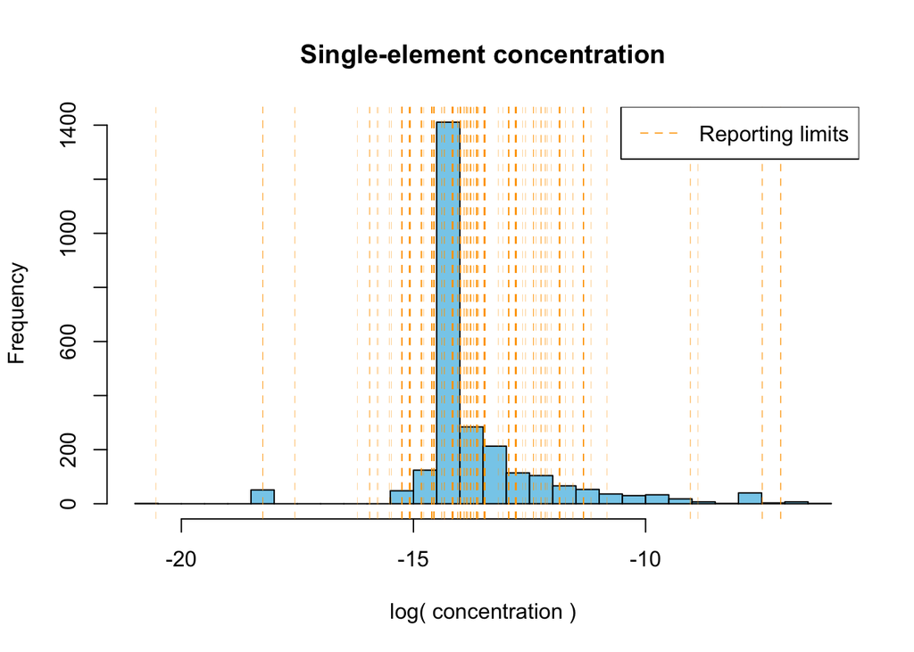

```r
# Plot the concentration: observed values histogram, reporting limits vertical lines
hist(log(one_element[!one_element$is_censored, ]$concentration),
     col = 'skyblue', breaks = 50, xlab = 'log( concentration )',
     main = 'Single-element concentration')
for (x in log(one_element[one_element$is_censored, ]$concentration)){
  abline(v = x, col = 'orange', lty = 'dashed', lwd = 0.25)
}
legend('topright', legend = 'Reporting limits', col = 'orange', lty = 'dashed', lwd = 0.8)
```

The summary statistics of the observed concentration on log-scale are:

```r
cbind(mean = mean(log(one_element[!one_element$is_censored, ]$concentration)),
      sd = sd(log(one_element[!one_element$is_censored, ]$concentration)))
```

```
##           mean       sd
## [1,] -13.66939 1.566165
```

## 2.2 Two-element

The two-element dataset contains 4,828 observations. The censoring proportion is 96.5% for element 1 and 93.5% for element 2. Together, the both censored data account for 92.6% of the total observations.

```r
# Number of observations
# 4828 in total
# nrow(two_elements)

# summary(two_elements)
# 171 observed for concentration 1, 312 observed for concentration 2
# There are 126 both observed
100 * round( table(two_elements[, 3:4]) / nrow(two_elements), 3 ) %>%
  addmargins()
```

```
##             is_censored2
## is_censored1 FALSE  TRUE   Sum
##        FALSE   2.6   0.9   3.5
##        TRUE    3.9  92.6  96.5
##        Sum     6.5  93.5 100.0
```

```r
# Check the reporting limit of concentration 1
# Range from 1.190e-06 to 1.047e-01
# summary(two_elements[two_elements$is_censored1, ]$concentration1)

# Check the reporting limit of concentration 2
# Range from 1.190e-06 to 1.047e-01
# summary(two_elements[two_elements$is_censored2, ]$concentration2)

# Check the range of observed values of concentration 1
# Range from 2.381e-06 to 7.619e-04
# summary(two_elements[!two_elements$is_censored1, ]$concentration1)

# Check the range of observed values of concentration 2
# Range from 1.190e-05 to 1.045e-01
# summary(two_elements[!two_elements$is_censored2, ]$concentration2)

# Check number of unique reporting limits 1
# 29 unique, 4657 total
# count(unique(two_elements[two_elements$is_censored1, 1]))

# Check number of unique reporting limits 2
# 29 unique, 4516 total
# count(unique(two_elements[two_elements$is_censored2, 2]))
```

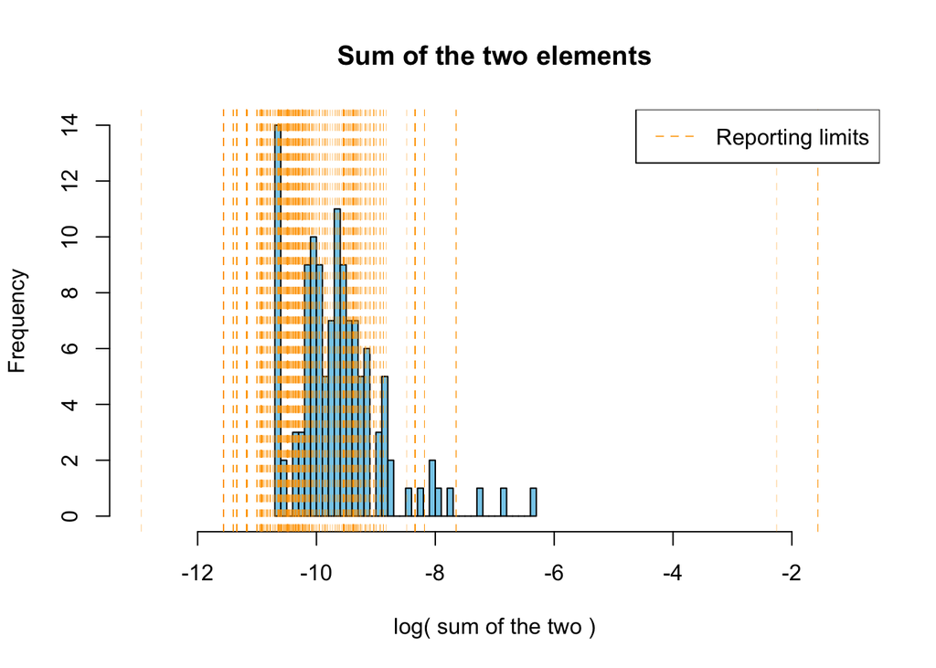

```r
two_elements_sum <- data.frame(sum = two_elements$concentration1 + two_elements$concentration2,
                               is_censored = two_elements$is_censored1 | two_elements$is_censored2)
# The range of the sum:
# Max: 2.093e-01 (which is censored)
# Min: 2.380e-06
# summary(two_elements_sum)
# two_elements_sum[which.max(two_elements_sum$sum), ]$is_censored

# Plot the sum of two concentrations: observed values histogram, reporting limits vertical lines
hist(log(two_elements_sum[!two_elements_sum$is_censored, ]$sum),
     xlim = c(-13, -1),
     col = 'skyblue', breaks = 50, xlab = 'log( sum of the two )',
     main = 'Sum of the two elements')
for (x in log(two_elements_sum[two_elements_sum$is_censored, ]$sum)){
  abline(v = x, col = 'orange', lty = 'dashed', lwd = 0.25)
}
legend('topright', legend = 'Reporting limits', col = 'orange', lty = 'dashed', lwd = 0.8)
```

```r
cbind(element1 = c(mean = mean(log(two_elements[two_elements$is_censored1, ]$concentration1)),
        sd = sd(log(two_elements[two_elements$is_censored1, ]$concentration1))),
      element2 = c(mean = mean(log(two_elements[two_elements$is_censored2, ]$concentration2)),
        sd = sd(log(two_elements[two_elements$is_censored2, ]$concentration2))))
```

```
##        element1   element2
## mean -11.138782 -11.060610
## sd     1.251428   1.279667
```

# 3 Bayesian modeling

## 3.1 Single-element

### 3.1.1 Metropolis

We applied the Metropolis algorithm to single-element data to approximate the posterior distributions of the log population mean and log standard deviation, assuming a log-normal model. We used uninformative priors and an adaptive algorithm to tune the proposal step size (see more details in Appendix). Justifications for our prior choices, proposal adaptation, and assessments of model performance (via convergence diagnostics and posterior predictive checks) are provided in the following subsections.

All computations were performed on the log scale for the following reasons:

- **Numerical stability:** Log-transforming concentration values (which are close to zero) prevents underflow issues when computing products and ratios—common in posterior evaluations and acceptance probability calculations—thus improving computational efficiency.
- **Model compatibility:** Since concentration data is assumed to follow a log-normal distribution, the parameters of interest are naturally the log-mean and log-standard deviation, making the log scale conceptually appropriate.

The algorithm runs efficiently, taking approximately 1 minute to complete 10,000 iterations across 3 chains on a 2.7 GHz Dual-Core Intel Core i5 processor.

```r
# Different initiates for three chains to allow better mixing
metro1_init_mu_vals <- c(-10, -15, -20)
metro1_init_sd_vals <- c(4, 4, 4)

system.time({
  metro1_results <- lapply(seq_along(metro1_init_mu_vals), function(i){
    set.seed(555 + i)
    metropolis1(one_element, num_iter = 10000,
                init_mu = metro1_init_mu_vals[i], # initial log data mean
                init_sd = metro1_init_sd_vals[i], # initial log data sd
                mu.prior = c(-14, 10), # prior of log data mean: mu0, sd0
                sd.prior.scale = 5) # prior of log data sd: half-cauchy scale
  })
})
```

```
##    user  system elapsed
##  41.932   7.859  61.621
```

```r
metro1_chains <- lapply(metro1_results, '[[', 'chain')
```

#### 3.1.1.1 Priors

We adopted the noninformative priors suggested in the ChatGPT code provided by the teaching team:

$$\mu \sim \text{Normal}(-14, 10^2)$$
$$\sigma \sim \text{Half-Cauchy}(0, 5)$$

**Justifications:**

- The log population mean $\mu$ lies on the entire real line, making the normal distribution a natural noninformative prior. We center the prior at –14, close to the sample log-mean of the observed data, and use a large standard deviation (e.g., 10) to ensure wide support and weak informativeness.
- The log population standard deviation $\sigma$ must be positive. The half-Cauchy distribution is commonly used for scale parameters due to its positive support and heavy right tail, allowing broad exploration. We set the location to 0 and use a scale of 5, permitting moderate flexibility without being overly diffuse.

#### 3.1.1.2 Convergence diagnostics

**Trace plots, Gelman-Rubin $\hat R$ and Effective Sample Size (ESS)**

Below are the trace plots for the post-burn-in chains of $\mu$ and $\sigma$. For each parameter, we performed 3 chains, each colored differently in the plots. In both plots, all three chains oscillate around a central value, indicating they are exploring the posterior without getting stuck. The significant intertwining of the chains suggests good mixing and likely convergence.

The Gelman-Rubin $\hat{R}$ and effective sample size (ESS) for the combined chains (length 15,000) are also shown. The $\hat{R}$ is close to 1, indicating statistically good convergence, and the ESS is moderate, considering the large repetition in the data.

```r
metro1_conv_stats <- compute_convergence_stats(metro1_chains)
```

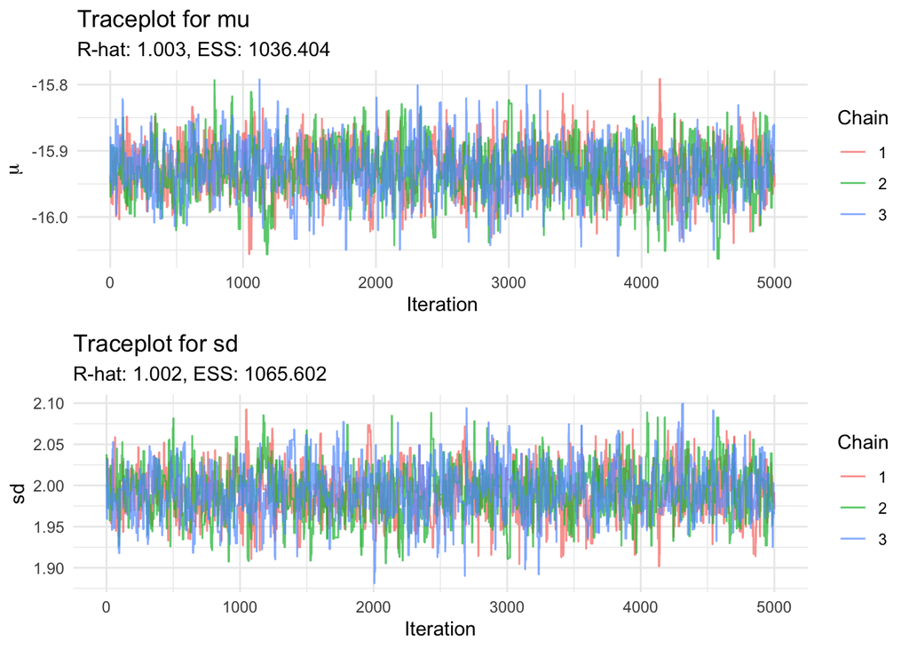

```r
# Convert list of chains to data frame
metro1_trace <- do.call(rbind, lapply(seq_along(metro1_chains), function(i) {
  chain_data <- metro1_chains[[i]]  # Extract chain i
  data.frame(
    iter = rep(1:nrow(chain_data), length.out = nrow(chain_data)),
    chain = rep(i, nrow(chain_data)),
    mu = chain_data[, "mu"],
    sd = chain_data[, "sd"],
    param = rep(c("mu", "sd"), each = nrow(chain_data))
  )
}))

# Traceplot for mu
p_mu <- ggplot(subset(metro1_trace, param == "mu"), aes(x = iter, y = mu, color = factor(chain))) +
  geom_line(alpha = 0.7) +
  labs(
    title = "Traceplot for mu",
    subtitle = paste0("R-hat: ", round(as.numeric(metro1_conv_stats[1, 'rhat']), 3),
                      ", ESS: ", round(as.numeric(metro1_conv_stats[1, 'ess']), 3)),
    x = "Iteration", y = expression(mu), color = "Chain"
  ) +
  theme_minimal()

# Traceplot for sigma
p_sd <- ggplot(subset(metro1_trace, param == "sd"), aes(x = iter, y = sd, color = factor(chain))) +
  geom_line(alpha = 0.7) +
  labs(
    title = "Traceplot for sd",
    subtitle = paste0("R-hat: ", round(as.numeric(metro1_conv_stats[2, 'rhat']), 3),
                      ", ESS: ", round(as.numeric(metro1_conv_stats[2, 'ess']), 3)),
    x = "Iteration", y = expression(sd), color = "Chain"
  ) +
  theme_minimal()

# Show both plots together
grid.arrange(p_mu, p_sd, ncol = 1)
```

**Autocorrelation plots (ACF)**

We plotted the autocorrelation function (ACF) for each chain and each parameter. The plots show a similar pattern: the correlation decreases quickly after a few lags as the lag increases. However, some autocorrelation remains, possibly due to the dependence structure of the original data.

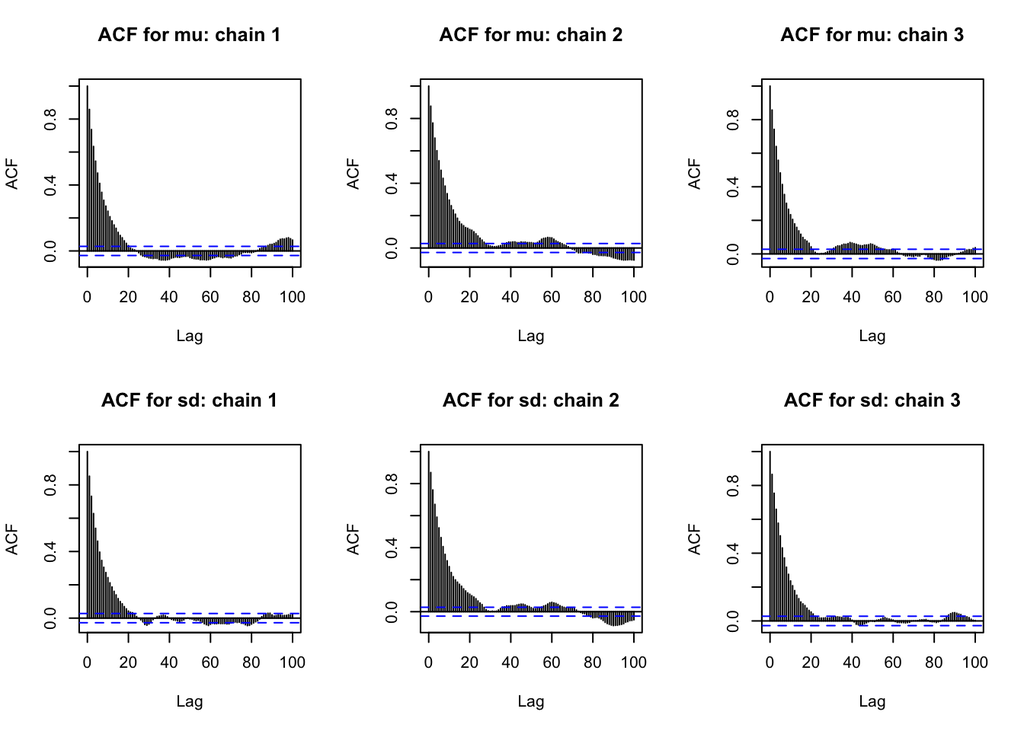

```r
par(mfrow = c(2, 3))
for (i in 1:length(metro1_chains)) {
  acf(metro1_chains[[i]][, 1], main = paste0("ACF for mu: chain ", i), lag.max = 100)
}
for (i in 1:length(metro1_chains)) {
  acf(metro1_chains[[i]][, 2], main = paste0("ACF for sd: chain ", i), lag.max = 100)
}
```

We combined the 3 chains and thinned the data by a factor of 10, resulting in a posterior with 1,500 rows. The ACF now looks much better, though thinning has reduced the effective sample size.

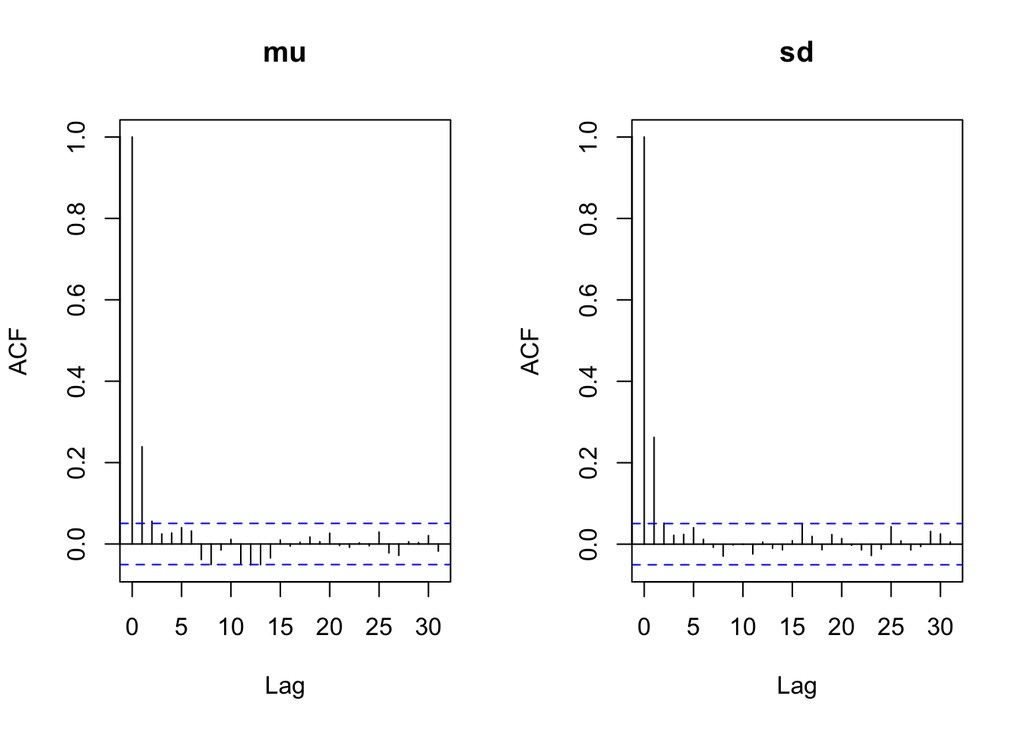

```r
# Combine all the chains (rows from each chain are stacked together)
metro1_combined_chains <- do.call(rbind, metro1_chains)

# Thin the combined posterior samples by selecting every nth row
thin_interval <- 10  # Choose thinning interval (e.g., every 10th sample)
metro1_posterior <- metro1_combined_chains[seq(1, nrow(metro1_combined_chains), thin_interval), ]

par(mfrow = c(1, 2))
acf(metro1_posterior[, 1], main = 'mu')
acf(metro1_posterior[, 2], main = 'sd')
```

#### 3.1.1.3 Model checking: goodness of fit

**Posterior Predictive Check (PPC)**

With the thinned posterior, we performed a posterior check. First, we compared the predictive distribution with the original data. Second, we examined the posterior predictive distribution for the maximum concentration and the 99.9% quantile, checking whether the true values fall within the predictive distribution (via p-values).

To compare the predictive distribution with the original data, we plotted both on the same log-scale graph (shown below). The blue line represents the predictive CDF (assumed normal on the log scale), the red dots are the uncensored observations, and the green dots are the reporting limits for censored data.

The red points mostly lie on the upper portion of the blue curve, suggesting the predictive distribution captures the upper tail of the observed data well. This could indicate a miscalibrated model, as it implies many uncensored observations come from the extreme right tail (above the 80% quantile) of the assumed distribution, which is unlikely under a good model. Alternatively, this may reflect the fact that uncensored data make up only 23% of the sample and genuinely represent the upper tail of the underlying distribution.

The green points are scattered across the y-axis, highlighting the strong influence of censoring on the distribution and suggesting that direct CDF comparisons may be misleading in the presence of heavy censoring.

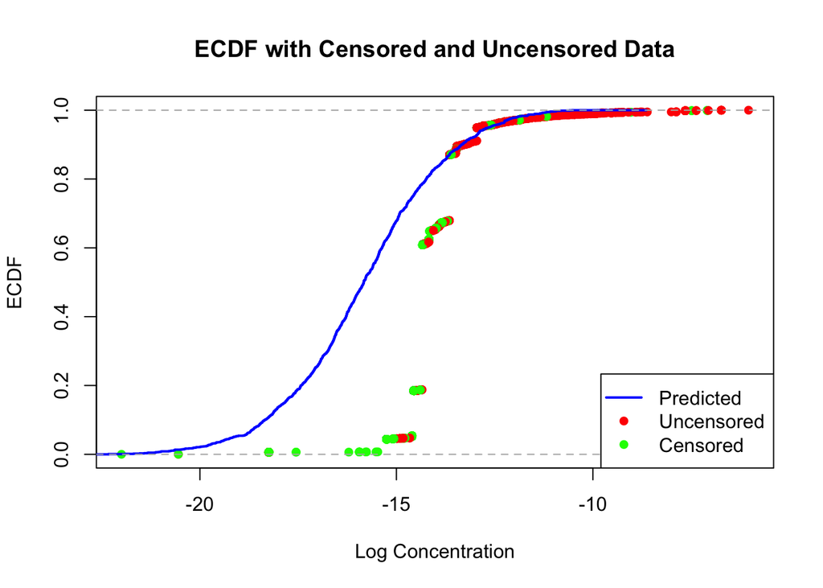

```r
# Log-transform all values
log_conc <- log(one_element$concentration)
is_cens  <- one_element$is_censored

# Compute ECDF
ecdf_vals <- ecdf(log_conc)
y_vals <- ecdf_vals(log_conc)

# Plot Empirical Cumulative Distribution Function(ECDF) as points with different colors
plot(log_conc, y_vals, col = ifelse(is_cens, "green", "red"),
     pch = 16, xlab = "Log Concentration", ylab = "ECDF",
     main = "ECDF with Censored and Uncensored Data")

# Add simulated ECDF line
metro1_logyhat <- rnorm(nrow(metro1_posterior), metro1_posterior[, 1], metro1_posterior[, 2])
lines(ecdf(metro1_logyhat), col = "blue", lwd = 2)

# Add legend
legend("bottomright", legend = c("Predicted", "Uncensored", "Censored"),
       col = c("blue", "red", "green"), pch = c(NA, 16, 16), lty = c(1, NA, NA), lwd = c(2, NA, NA))
```

Next, we present the posterior predictive checks for the maximum and the 99.9% quantile. Why these two statistics? In standard (uncensored) settings, posterior predictive checks are typically performed using the predictive mean by simulating one dataset from each posterior draw $\theta_i, \ i = 1, \dots, S$. However, due to censoring, we cannot reliably estimate the population mean—only the upper tail of the distribution is fully observed.

We found that values above the 99.9% quantile are entirely uncensored, making them reliable targets for comparison. For each posterior sample, we computed the 99.9% quantile and maximum of the predictive dataset, thereby integrating over uncertainty in $\theta$, and obtained predictive distributions for these two statistics (shown in blue).

We then compared these to the corresponding observed values, shown as red dashed lines. Ideally, under a well-calibrated model, the observed statistics should fall near the center (e.g., 50th percentile) of the predictive distribution. However, both the observed maximum and 99.9% quantile lie far to the right of the predictive distributions, with p-values close to 0—suggesting that the model underestimates the upper tail and does not fit the data well.

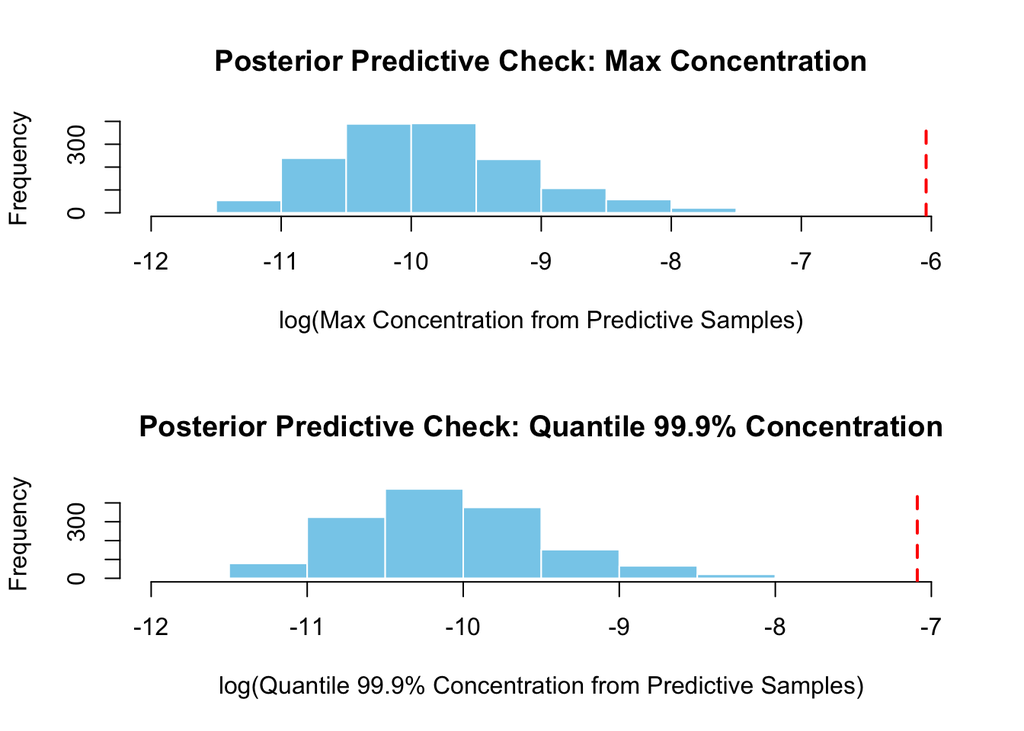

```r
# The top 0.1% are observed
# one_element[one_element$concentration > quantile(one_element$concentration, 0.999), ]

n_rep <- 500
set.seed(333)
metro1_maxhat <- numeric()
metro1_q999hat <- numeric()
metro1_gmhat <- numeric()
metro1_gsdhat <- numeric()
metro1_amhat <- numeric()
metro1_q95hat <- numeric()
for (i in 1:nrow(metro1_posterior)){
  logyhats <- rnorm(n_rep,
                  mean = metro1_posterior[i, 1],
                  sd = metro1_posterior[i, 2])
  metro1_maxhat[i] <- max(exp(logyhats))
  metro1_q999hat[i] <- quantile(exp(logyhats), 0.999)
  metro1_gmhat[i] <- exp(mean(logyhats))
  metro1_gsdhat[i] <- exp(sd(logyhats))
  metro1_amhat[i] <- mean(exp(logyhats))
  metro1_q95hat[i] <- quantile(exp(logyhats), 0.95)
}

# Store the estimands for later use
metro1_est <- data.frame(
  GM = metro1_gmhat,
  GSD = metro1_gsdhat,
  AM = metro1_amhat,
  Q95 = metro1_q95hat,
  method = 'Metropolis'
)

par(mfrow = c(2, 1))
hist(log(metro1_maxhat),
     col = "skyblue",
     border = "white",
     main = "Posterior Predictive Check: Max Concentration",
     xlab = "log(Max Concentration from Predictive Samples)")

abline(v = log(max(one_element$concentration)),
       col = "red",
       lwd = 2,
       lty = 2)  # dashed line

hist(log(metro1_q999hat),
     col = "skyblue",
     border = "white",
     main = "Posterior Predictive Check: Quantile 99.9% Concentration",
     xlab = "log(Quantile 99.9% Concentration from Predictive Samples)")

abline(v = log(quantile(one_element$concentration, 0.999)),
       col = "red",
       lwd = 2,
       lty = 2)  # dashed line
```

### 3.1.2 Gibbs sampler

#### 3.1.2.1 Priors

We also implemented a Gibbs sampler using a semi-conjugate prior based on the Normal–Inverse-Gamma distribution and data augmentation via sampling from truncated normal distributions. The prior assumes independence between the population mean $\mu$ and variance $\sigma^2$, leading to a semi-conjugate structure:
$$\mu \sim \mathcal{N}(\mu_0, \tau_0^2), \quad \frac{1}{\sigma^2} \sim
\text{Inverse-Gamma}(\nu_0/2, \nu_0 \sigma_0^2/2).$$

The Gibbs sampler alternates between:

- Imputing censored values from truncated normal distributions (data augmentation), and
- Sampling $\mu$ and $\sigma^2$ from their full conditional posterior distributions given the completed data.

The initial values of data mean and standard deviation randomly sampled from the priors.

Same as the Metropolis, the Gibbs algorithm runs efficiently on this single-element data, taking approximately 1 minute to complete 10,000 iterations across 3 chains on a 2.7 GHz Dual-Core Intel Core i5 processor.

```r
# Different priors for three chains to allow better mixing
# Three different priors for three chains (only change mu0)
gibbs1_priors <- vector('list', 3)
tau2_0 <- 4; nu0 <- 2; sigma2_0 <- 1
gibbs1_priors[[1]] <- list(mu0 = -10, tau2_0 = tau2_0, nu0 = nu0, sigma2_0 = sigma2_0)
gibbs1_priors[[2]] <- list(mu0 = -13, tau2_0 = tau2_0, nu0 = nu0, sigma2_0 = sigma2_0)
gibbs1_priors[[3]] <- list(mu0 = -16, tau2_0 = tau2_0, nu0 = nu0, sigma2_0 = sigma2_0)

log_one_element <- one_element
log_one_element[, 1] <- log(one_element$concentration)
system.time({
  gibbs1_chains <- lapply(gibbs1_priors, function(priors){
    set.seed(666 + i)
    gibbs1(log_one_element,
           priors = priors,
           iter = 5000,
           burnin = 5000)
  })
})
```

```
##    user  system elapsed
##  40.562   8.505  59.229
```

#### 3.1.2.2 Convergence diagnostics

We performed the same convergence diagnostics for the Gibbs sampler as we did for the Metropolis algorithm. This includes examining trace plots, Gelman-Rubin statistic ($\hat{R}$), Effective Sample Size (ESS), and autocorrelation plots. The diagnostics indicate similar performance to the Metropolis sampler, with good mixing and convergence across the chains.

```r
gibbs1_conv_stats <- compute_convergence_stats(gibbs1_chains)
```

**Trace plots, Gelman-Rubin $\hat R$, Effective Sample Size (ESS)**

Below are the trace plots of the three post-burn-in chains for $\mu$ and $\sigma$, respectively. Displayed alongside each plot are the Gelman-Rubin statistic ($\hat{R}$) and Effective Sample Size (ESS) based on the combined chains (total length 15, 000).

The trace plots show excellent mixing, with the three chains overlapping significantly and exhibiting no apparent trends or drifts. The Gelman-Rubin $\hat{R}$ values are well below 1.1, indicating good convergence. The ESS values are high, further confirming that the Gibbs sampler converges efficiently.

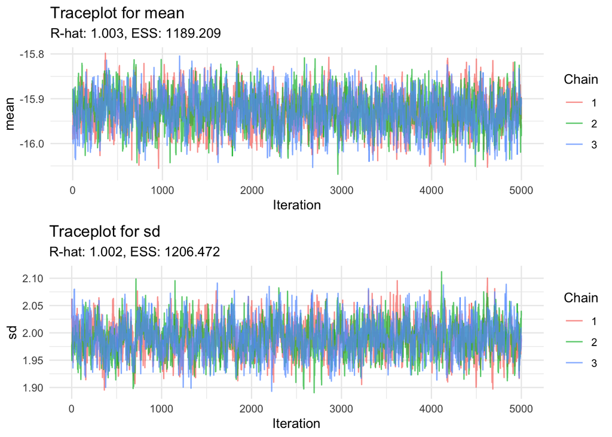

```r
# Convert list of chains to data frame
gibbs1_trace <- do.call(rbind, lapply(seq_along(gibbs1_chains), function(i) {
  chain_data <- gibbs1_chains[[i]]  # Extract chain i
  data.frame(
    iter = rep(1:nrow(chain_data), length.out = nrow(chain_data)),
    chain = rep(i, nrow(chain_data)),
    mean = chain_data[, "mean"],
    sd = chain_data[, "sd"],
    param = rep(c("mean", "sd"), each = nrow(chain_data))
  )
}))

# Traceplot for mean
p_mean <- ggplot(subset(gibbs1_trace, param == "mean"), aes(x = iter, y = mean, color = factor(chain))) +
  geom_line(alpha = 0.7) +
  labs(
    title = "Traceplot for mean",
    subtitle = paste0("R-hat: ", round(as.numeric(gibbs1_conv_stats[1, 'rhat']), 3),
                      ", ESS: ", round(as.numeric(gibbs1_conv_stats[1, 'ess']), 3)),
    x = "Iteration", y = expression(mean), color = "Chain"
  ) +
  theme_minimal()

# Traceplot for sigma
p_sd <- ggplot(subset(gibbs1_trace, param == "sd"), aes(x = iter, y = sd, color = factor(chain))) +
  geom_line(alpha = 0.7) +
  labs(
    title = "Traceplot for sd",
    subtitle = paste0("R-hat: ", round(as.numeric(gibbs1_conv_stats[2, 'rhat']), 3),
                      ", ESS: ", round(as.numeric(gibbs1_conv_stats[2, 'ess']), 3)),
    x = "Iteration", y = expression(sd), color = "Chain"
  ) +
  theme_minimal()

# Show both plots together
grid.arrange(p_mean, p_sd, ncol = 1)
```

**Autocorrelation plots (ACF)**

The autocorrelation functions (ACFs) for each parameter across all chains show similar patterns to those observed in the Metropolis algorithm. Specifically, the autocorrelations drop sharply after the first few lags, though the lag-1 ACF remains high. This initial autocorrelation may reflect the strong dependence structure inherent in the data.

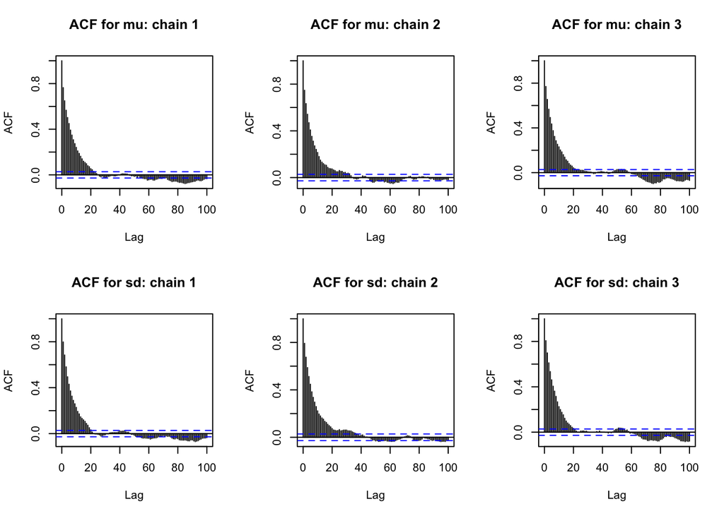

```r
par(mfrow = c(2, 3))
for (i in 1:length(gibbs1_chains)) {
  acf(gibbs1_chains[[i]][, 1], main = paste0("ACF for mu: chain ", i), lag.max = 100)
}

for (i in 1:length(gibbs1_chains)) {
  acf(gibbs1_chains[[i]][, 2], main = paste0("ACF for sd: chain ", i), lag.max = 100)
}
```

We combined and thinned the chains, resulting in a posterior sample with reduced autocorrelation and more favorable ACF plots, though ESS may also drops.

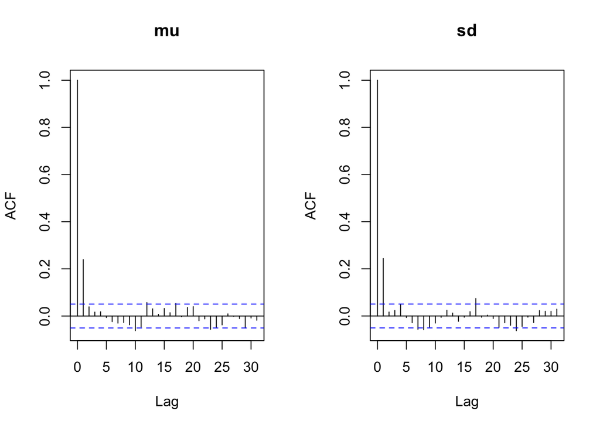

```r
# Combine all the chains (rows from each chain are stacked together)
gibbs1_combined_chains <- do.call(rbind, gibbs1_chains)

# Thin the combined posterior samples by selecting every nth row
thin_interval <- 10  # Choose thinning interval (e.g., every 10th sample)
gibbs1_posterior <- gibbs1_combined_chains[seq(1, nrow(gibbs1_combined_chains), thin_interval), ]

par(mfrow = c(1, 2))
acf(gibbs1_posterior[, 1], main = 'mu')
acf(gibbs1_posterior[, 2], main = 'sd')
```

#### 3.1.2.3 Model checking: goodness of fit

We conducted the same model checking using both the empirical CDF comparison and posterior predictive checks. The results are similar to those from the Metropolis algorithm: the Gibbs sampler does not fit the data well.

- Empirical CDF of the predictive distribution
- Observed (uncensored) data points
- Reporting limits (censored data points)

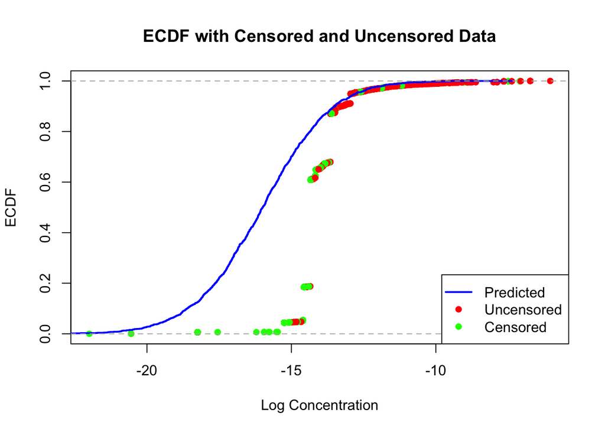

```r
# Log-transform all values
log_conc <- log(one_element$concentration)
is_cens  <- one_element$is_censored

# Compute ECDF
ecdf_vals <- ecdf(log_conc)
y_vals <- ecdf_vals(log_conc)

# Plot Empirical Cumulative Distribution Function(ECDF) as points with different colors
plot(log_conc, y_vals, col = ifelse(is_cens, "green", "red"),
     pch = 16, xlab = "Log Concentration", ylab = "ECDF",
     main = "ECDF with Censored and Uncensored Data")

# Add simulated ECDF line
gibbs1_logyhat <- rnorm(nrow(gibbs1_posterior), gibbs1_posterior[, 1], gibbs1_posterior[, 2])
lines(ecdf(gibbs1_logyhat), col = "blue", lwd = 2)

# Add legend
legend("bottomright", legend = c("Predicted", "Uncensored", "Censored"),
       col = c("blue", "red", "green"), pch = c(NA, 16, 16), lty = c(1, NA, NA), lwd = c(2, NA, NA))
```

As shown in the plots, the observed values for the maximum concentration and the 99.9% quantile lie far to the right of their respective predictive distributions. This results in p-values close to 0, whereas, under a good model fit, we would expect the p-values to be close to 0.5. This suggests that the model is not accurately capturing the upper tail of the distribution, further supporting the conclusion that the Gibbs sampler is not performing well in terms of fitting this extremely censored data.

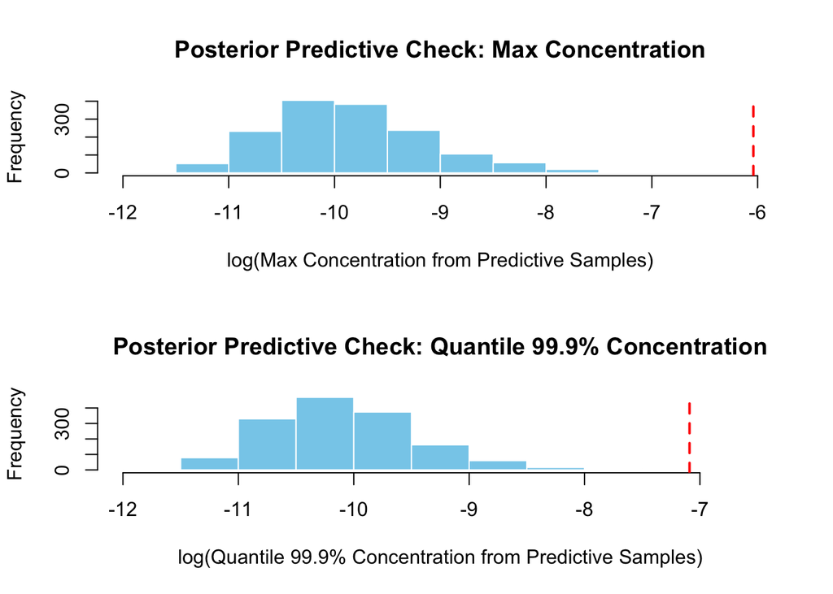

```r
# The top 0.1% are observed
# one_element[one_element$concentration > quantile(one_element$concentration, 0.999), ]

n_rep <- 500
set.seed(333)
gibbs1_maxhat <- numeric()
gibbs1_q999hat <- numeric()
gibbs1_gmhat <- numeric()
gibbs1_gsdhat <- numeric()
gibbs1_amhat <- numeric()
gibbs1_q95hat <- numeric()
for (i in 1:nrow(gibbs1_posterior)){
  logyhats <- rnorm(n_rep,
                  mean = gibbs1_posterior[i, 1],
                  sd = gibbs1_posterior[i, 2])
  gibbs1_maxhat[i] <- max(exp(logyhats))
  gibbs1_q999hat[i] <- quantile(exp(logyhats), 0.999)
  gibbs1_gmhat[i] <- exp(mean(logyhats))
  gibbs1_gsdhat[i] <- exp(sd(logyhats))
  gibbs1_amhat[i] <- mean(exp(logyhats))
  gibbs1_q95hat[i] <- quantile(exp(logyhats), 0.95)
}

# Store the estimands for later use
gibbs1_est <- data.frame(
  GM = gibbs1_gmhat,
  GSD = gibbs1_gsdhat,
  AM = gibbs1_amhat,
  Q95 = gibbs1_q95hat,
  method = 'Gibbs'
)

par(mfrow = c(2, 1))
hist(log(gibbs1_maxhat),
     col = "skyblue",
     border = "white",
     main = "Posterior Predictive Check: Max Concentration",
     xlab = "log(Max Concentration from Predictive Samples)")

abline(v = log(max(one_element$concentration)),
       col = "red",
       lwd = 2,
       lty = 2)  # dashed line

hist(log(gibbs1_q999hat),
     col = "skyblue",
     border = "white",
     main = "Posterior Predictive Check: Quantile 99.9% Concentration",
     xlab = "log(Quantile 99.9% Concentration from Predictive Samples)")

abline(v = log(quantile(one_element$concentration, 0.999)),
       col = "red",
       lwd = 2,
       lty = 2)  # dashed line
```

## 3.2 Two-element

### 3.2.1 Gibbs sampler

#### 3.2.1.1 Priors

We performed a Gibbs sampler on the two-element dataset using a semi-conjugate normal-inverse-Wishart prior in the bivariate case. Specifically, we used the following priors:

- The data mean follows a bivariate normal distribution:
  $$\mu \sim N_2(\mu_0, L_0 L_0^T)$$
  where $\mu_0$ is the prior mean, and $L_0$ is the covariance matrix, which is set to reflect the correlation structure of the data.
- The precision (inverse of the covariance) follows an inverse Wishart distribution:
  $$\frac{1}{\sigma^2} \sim \text{Inverse-Wishart}(\nu_0, S_0)$$
  where $\nu_0$ is the degrees of freedom and $S_0$ is the scale matrix.

Three chains were run, similar to the single-element case. For each chain, we used different priors, with the only difference being the mean $\mu_0$ of the bivariate normal distribution. The values for $\mu_0$ (the prior mean) were set using the same reasoning as in the single-element case. These priors were chosen to be close to the sample mean of the observed data. A large variance was specified to allow for full exploration of the parameter space, and the correlation was set high to reflect the strong correlation in the data. The prior for the data covariance matrix was noninformative, and controled the dispersion of the data covariance with small $S_0$.

It took much longer to run this two-element model on the same 2.7 GHz Dual-Core Intel Core i5 processor, almost 5 minutes.

```r
# Different priors for three chains to allow better mixing
# Three different priors for three chains (only change mu0)
gibbs2_priors <- vector('list', 3)
# Cov-var for prior of mu, not change
L <- matrix(c(50, 40, 40, 50), nrow = 2) # The two elements are highly correlation
L.inv <- solve(L)
nu <- 4; S <- diag(2) # Prior of sigma2: inverse-Wh
gibbs2_priors[[1]] <- list(mu = rep(-8, 2), L = L, L.inv = L.inv, nu = nu, S = S)
gibbs2_priors[[2]] <- list(mu = rep(-10, 2), L = L, L.inv = L.inv, nu = nu, S = S)
gibbs2_priors[[3]] <- list(mu = rep(-16, 2), L = L, L.inv = L.inv, nu = nu, S = S)

log_two_elements <- two_elements
log_two_elements[, 1:2] <- log(two_elements[, 1:2])
system.time({
  gibbs2_chains <- lapply(gibbs2_priors, function(priors){
    set.seed(666 + i)
    # Random initiation
    init_mean <- runif(2, -16, -10)
    init_sigma <- diag(runif(2, 2, 3))
    init <- list(mean = init_mean, Sigma = init_sigma)
    gibbs2(log_two_elements,
           priors = priors,
           init = init,
           iter = 5000,
           burnin = 5000)
  })
})
```

```
##    user  system elapsed
## 221.862  30.023 293.132
```

#### 3.2.1.2 Convergence diagnostics

We conducted convergence diagnostics using trace plots, Gelman-Rubin $\hat{R}$, Effective Sample Size (ESS), and autocorrelation (ACF). Although $\hat{R}$ is close to 1 for each parameter, the trace plots for $\mu_1$ and $\mu_2$ show significant issues. Specifically, they exhibit truncation in different directions, indicating that the chains are not converging well. This suggests that there might be an issue with the model or the sampling process that we need to investigate further.

One potential explanation could be the very low standard deviations (SD) observed when we ran the model on simulated data. This may be related to the approximation of the truncated bivariate normal distribution, which could be affecting convergence. Further investigation is required to understand the cause of this problem.

```r
gibbs2_chains <- lapply(gibbs2_chains, function(chain){
  df <- as.data.frame(chain)
  colnames(df) <- c('mu1', 'mu2', 'sd1', 'sd2', 'rho')
  df
})
gibbs2_conv_stats <- compute_convergence_stats(gibbs2_chains)
```

As shown in the plot, the trace plots for $\text{sd}_1$, $\text{sd}_2$, and $\rho$ are very good, showing perfect mixing and convergence. The trace plots for $\mu_1$ and $\mu_2$ also show mixing across the three chains, but they appear to be upper-capped and lower-floored, suggesting they are not stationary. This indicates the presence of some variance structure in the sequence. Further investigation is needed to diagnose and resolve this issue.

A highly plausible reason for the observed issue could be the use of the Gibbs sampler with a truncated conditional normal to approximate the bivariate truncated normal, chosen for computational efficiency. To better understand the impact of this approximation, we will conduct a comparison study between using the approximation and directly using the bivariate truncated normal for performance evaluation.

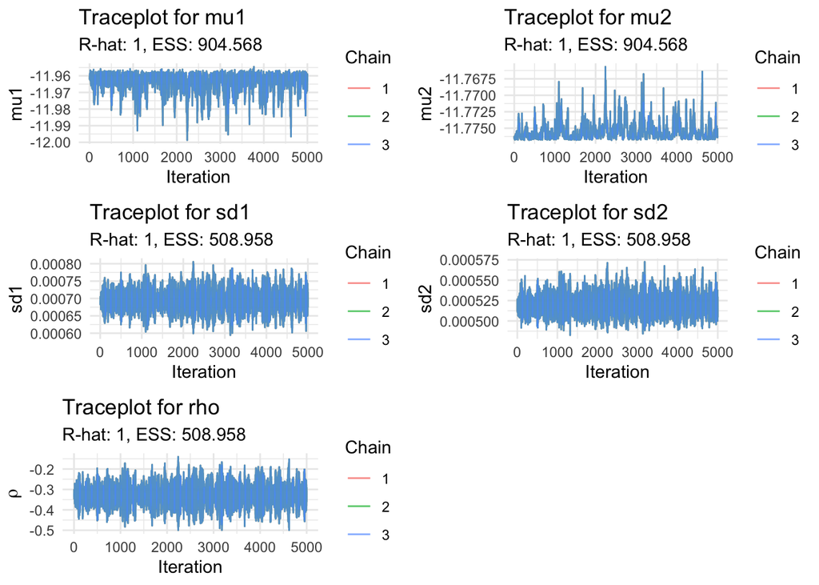

```r
# Convert list of chains to data frame
gibbs2_trace <- do.call(rbind, lapply(seq_along(gibbs2_chains), function(i) {
  chain_data <- gibbs2_chains[[i]]  # Extract chain i
  data.frame(
    iter = rep(1:nrow(chain_data), length.out = nrow(chain_data)),
    chain = rep(i, nrow(chain_data)),
    mu1 = chain_data[, "mu1"],
    mu2 = chain_data[, "mu2"],
    sd1 = chain_data[, "sd1"],
    sd2 = chain_data[, "sd2"],
    rho = chain_data[, "rho"],
    param = rep(c("mu1", "mu2", "sd1", "sd2", "rho"), each = nrow(chain_data))
  )
}))

# Traceplot for mu1
p_mu1 <- ggplot(subset(gibbs2_trace, param == "mu1"), aes(x = iter, y = mu1, color = factor(chain))) +
  geom_line(alpha = 0.7) +
  labs(
    title = "Traceplot for mu1",
    subtitle = paste0("R-hat: ", round(as.numeric(gibbs2_conv_stats[1, 'rhat']), 3),
                      ", ESS: ", round(as.numeric(gibbs2_conv_stats[1, 'ess']), 3)),
    x = "Iteration", y = expression(mu1), color = "Chain"
  ) +
  theme_minimal()

p_mu2 <- ggplot(subset(gibbs2_trace, param == "mu2"), aes(x = iter, y = mu2, color = factor(chain))) +
  geom_line(alpha = 0.7) +
  labs(
    title = "Traceplot for mu2",
    subtitle = paste0("R-hat: ", round(as.numeric(gibbs2_conv_stats[1, 'rhat']), 3),
                      ", ESS: ", round(as.numeric(gibbs2_conv_stats[1, 'ess']), 3)),
    x = "Iteration", y = expression(mu2), color = "Chain"
  ) +
  theme_minimal()

# Traceplot for sd1
p_sd1 <- ggplot(subset(gibbs2_trace, param == "sd1"), aes(x = iter, y = sd1, color = factor(chain))) +
  geom_line(alpha = 0.7) +
  labs(
    title = "Traceplot for sd1",
    subtitle = paste0("R-hat: ", round(as.numeric(gibbs2_conv_stats[2, 'rhat']), 3),
                      ", ESS: ", round(as.numeric(gibbs2_conv_stats[2, 'ess']), 3)),
    x = "Iteration", y = expression(sd1), color = "Chain"
  ) +
  theme_minimal()

p_sd2 <- ggplot(subset(gibbs2_trace, param == "sd2"), aes(x = iter, y = sd2, color = factor(chain))) +
  geom_line(alpha = 0.7) +
  labs(
    title = "Traceplot for sd2",
    subtitle = paste0("R-hat: ", round(as.numeric(gibbs2_conv_stats[2, 'rhat']), 3),
                      ", ESS: ", round(as.numeric(gibbs2_conv_stats[2, 'ess']), 3)),
    x = "Iteration", y = expression(sd2), color = "Chain"
  ) +
  theme_minimal()

p_rho <- ggplot(subset(gibbs2_trace, param == "rho"), aes(x = iter, y = rho, color = factor(chain))) +
  geom_line(alpha = 0.7) +
  labs(
    title = "Traceplot for rho",
    subtitle = paste0("R-hat: ", round(as.numeric(gibbs2_conv_stats[2, 'rhat']), 3),
                      ", ESS: ", round(as.numeric(gibbs2_conv_stats[2, 'ess']), 3)),
    x = "Iteration", y = expression(rho), color = "Chain"
  ) +
  theme_minimal()

# Show both plots together
grid.arrange(p_mu1, p_mu2, p_sd1, p_sd2, p_rho, ncol = 2)
```

**Autocorrelation plots (ACF)**

The ACF plots for each parameter and each chain show poor performance, indicating long-term dependence in the data.

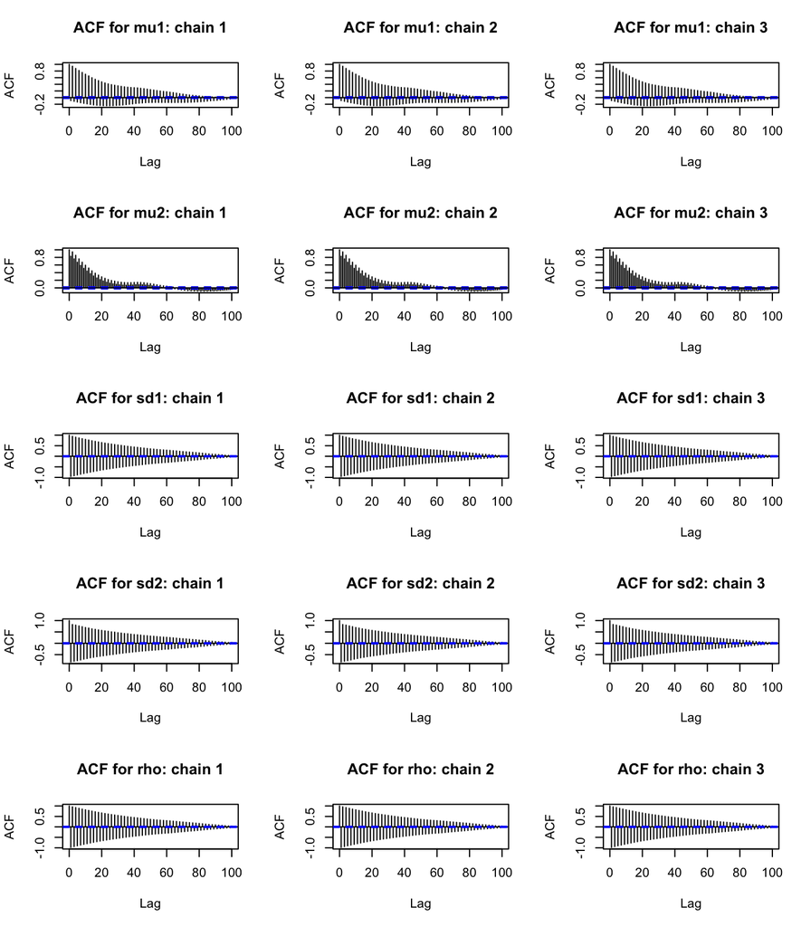

```r
par(mfrow = c(5, 3))
for (i in 1:length(gibbs2_chains)) {
  acf(gibbs2_chains[[i]][, 1], main = paste0("ACF for mu1: chain ", i), lag.max = 100)
}

for (i in 1:length(gibbs2_chains)) {
  acf(gibbs2_chains[[i]][, 2], main = paste0("ACF for mu2: chain ", i), lag.max = 100)
}

for (i in 1:length(gibbs2_chains)) {
  acf(gibbs2_chains[[i]][, 3], main = paste0("ACF for sd1: chain ", i), lag.max = 100)
}

for (i in 1:length(gibbs2_chains)) {
  acf(gibbs2_chains[[i]][, 4], main = paste0("ACF for sd2: chain ", i), lag.max = 100)
}

for (i in 1:length(gibbs2_chains)) {
  acf(gibbs2_chains[[i]][, 5], main = paste0("ACF for rho: chain ", i), lag.max = 100)
}
```

Even after combining and thinning the chains, several lags still exhibit strong autocorrelation.

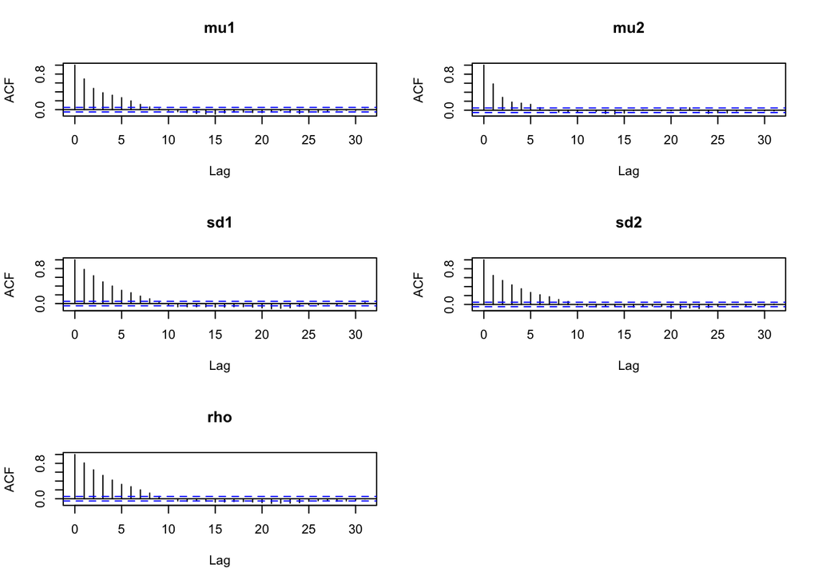

```r
# Combine all the chains (rows from each chain are stacked together)
gibbs2_combined_chains <- do.call(rbind, gibbs2_chains)

# Thin the combined posterior samples by selecting every nth row
thin_interval <- 10  # Choose thinning interval (e.g., every 10th sample)
gibbs2_posterior <- gibbs2_combined_chains[seq(1, nrow(gibbs2_combined_chains), thin_interval), ]

par(mfrow = c(3, 2))
acf(gibbs2_posterior[, 1], main = 'mu1')
acf(gibbs2_posterior[, 2], main = 'mu2')
acf(gibbs2_posterior[, 3], main = 'sd1')
acf(gibbs2_posterior[, 4], main = 'sd2')
acf(gibbs2_posterior[, 5], main = 'rho')
```

#### 3.2.1.3 Model checking: goodness of fit

We performed a ECDF check of the sum of the two elements between the predictive distribution and the observed values to see possible overlapping of the predictive distribution and the original data. As before, the blue line represents the predicted values, the red dots are the observed values (both elements observed), and the green dots are censored. Not surprisingly, the fit of the model is poor, as the convergence was not achieved. Ideally, we should not proceed with such poor convergence, but due to time constraints, we present the analysis with the understanding that the convergence is inadequate and the posterior is not plausible. As mentioned earlier, the model’s output SDs are very small, which is why the blue line appears almost vertical.

In addition to the issues with the model itself, the high repetition of the data could be contributing to the poor fit. We have fewer than 300 unique values out of over 4,800 observations.

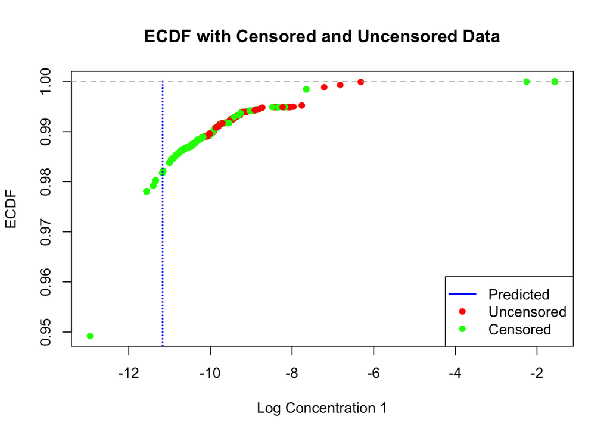

```r
# Log-transform all values
log_sum <- log(two_elements_sum$sum)
is_cens  <- two_elements_sum$is_censored

# Compute ECDF
ecdf_sum <- ecdf(log_sum)
y_vals <- ecdf_vals(log_sum)

# Plot Empirical Cumulative Distribution Function(ECDF) as points with different colors
plot(log_sum, y_vals, col = ifelse(is_cens, "green", "red"),
     pch = 16, xlab = "Log Concentration 1", ylab = "ECDF",
     main = "ECDF with Censored and Uncensored Data")

# Add simulated ECDF line
gibbs2_ysum <- numeric(nrow(gibbs2_posterior))
set.seed(333)
for (i in 1:nrow(gibbs2_posterior)){
  mu <- as.numeric(gibbs2_posterior[i, 1:2])
  cov <- gibbs2_posterior[i, 3] * gibbs2_posterior[i, 4] * gibbs2_posterior[i, 5]
  S <- matrix(c(gibbs2_posterior[i, 3]^2, cov, cov, gibbs2_posterior[i, 4]^2), nrow = 2)
  gibbs2_ysum[i] <- sum(exp(rmvnorm(1, mu, S)))
}

lines(ecdf(log(gibbs2_ysum)), col = "blue", lwd = 2)

# Add legend
legend("bottomright", legend = c("Predicted", "Uncensored", "Censored"),
       col = c("blue", "red", "green"), pch = c(NA, 16, 16), lty = c(1, NA, NA), lwd = c(2, NA, NA))
```

Despite the poor performance of the model, we proceeded with the computation of the requested estimands to demonstrate the process.

```r
# The top 0.1% are observed
# one_element[one_element$concentration > quantile(one_element$concentration, 0.999), ]

n_rep <- 500
set.seed(333)
gibbs2_gmhat <- numeric()
gibbs2_gsdhat <- numeric()
gibbs2_amhat <- numeric()
gibbs2_q95hat <- numeric()
for (i in 1:nrow(gibbs2_posterior)){
  mu <- as.numeric(gibbs2_posterior[i, 1:2])
  cov <- gibbs2_posterior[i, 3] * gibbs2_posterior[i, 4] * gibbs2_posterior[i, 5]
  S <- matrix(c(gibbs2_posterior[i, 3]^2, cov, cov, gibbs2_posterior[i, 4]^2), nrow = 2)

  yhats <- exp(rmvnorm(n_rep, mu, S))
  ysum <- rowSums(yhats)
  logysum <- log(ysum)

  gibbs2_gmhat[i] <- exp(mean(logysum))
  gibbs2_gsdhat[i] <- exp(sd(logysum))
  gibbs2_amhat[i] <- mean(ysum)
  gibbs2_q95hat[i] <- quantile(ysum, 0.95)
}

# Store the estimands for later use
gibbs2_est <- data.frame(
  GM = gibbs2_gmhat,
  GSD = gibbs2_gsdhat,
  AM = gibbs2_amhat,
  Q95 = gibbs2_q95hat,
  method = 'Gibbs'
)
```

# 4 Frequentist modelling

Three frequentist methods were used to model both the single-element and two-element data:

- ROS
- Substitution (with factors $\frac{1}{2}$, $\frac{1}{\sqrt{2}}$)
- Beta substitution (with $\beta(2, 2)$)

A potential issue is that we imputed the data separately for the two elements, which is problematic since they are highly correlated. Treating them independently assumes no dependence, which is not the case. However, since this project focuses primarily on Bayesian methods, we did not spend time exploring alternatives for dependent data.

For the Frequentist methods, we could only obtain point estimates for all the estimands. In the case of the arithmetic mean (AM), if the data were independent, it would be possible to compute confidence intervals using the Central Limit Theorem. However, since our observations are highly dependent, we cannot apply this, so we only report the point estimates.

```r
freq1_est <- data.frame(
  rbind(
    ros1(one_element),
      sub1(one_element, 0.5),
      sub1(one_element, 1/sqrt(2)),
      beta1(one_element)
  )) %>%
  mutate(across(-method, as.numeric))

mu_sd_freq1 <- freq1_est %>%
  mutate(mu = log(GM), sd = log(GSD)) %>%
  dplyr::select(mu, sd, method)

freq2_est <- rbind(
      ros2(two_elements),
      sub2(two_elements, rep(0.5, 2)),
      sub2(two_elements, rep(1/sqrt(2), 2)),
      beta2(two_elements)
    )
```

# 5 Results

## 5.1 Single-element

We combined the results from both Bayesian and Frequentist methods to estimate the log data mean and standard deviation, and plotted them on the same graph, with $\mu$ and $\sigma$ on the two axes, as shown below. Since the Bayesian methods yield posterior distributions, we observe a cloud of points, with the two methods producing very similar posteriors that almost overlap. On the other hand, the Frequentist methods provide only point estimates, represented by triangular-shaped points.

The Bayesian methods’ posterior distributions form a dense cloud of points that nearly overlap, while the Frequentist methods’ results are spread apart. Specifically, the substitution method results are grouped in the bottom right corner, showing small $\sigma$ and large $\mu$. The ROS method, conversely, has results in the opposite region, with large $\sigma$ and small $\mu$. The Bayesian posterior lies in the middle of the diagonal, between the two Frequentist methods.

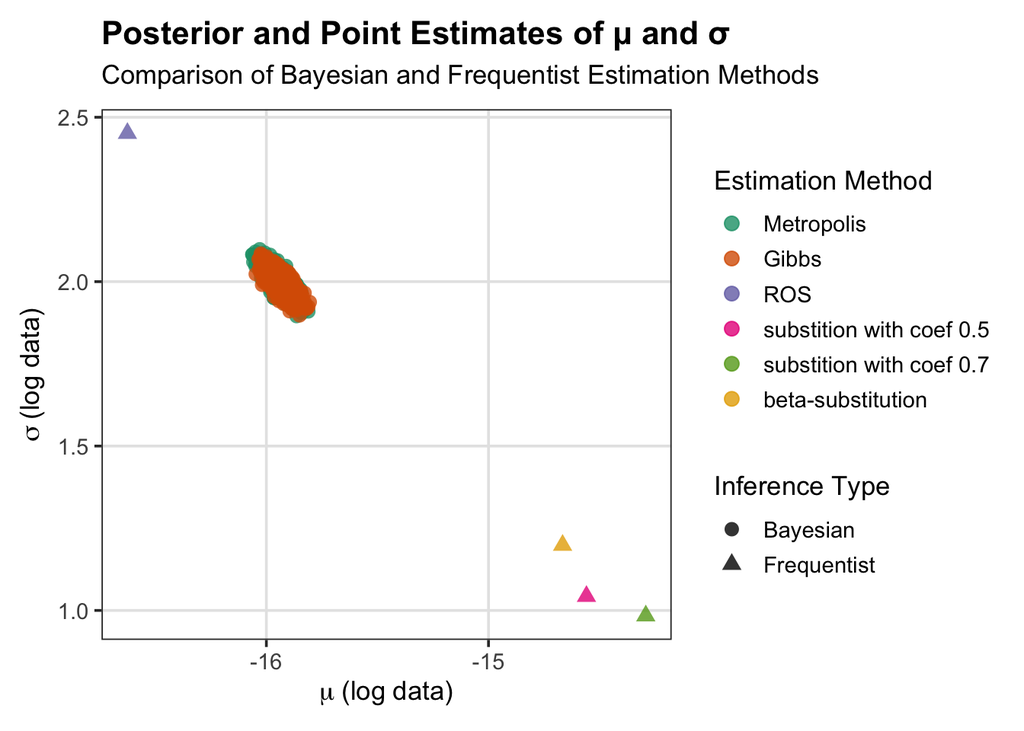

```r
metro1_posterior <- as.data.frame(metro1_posterior)
gibbs1_posterior <- as.data.frame(gibbs1_posterior)
colnames(metro1_posterior) <- c("mu", "sd")
colnames(gibbs1_posterior) <- c("mu", "sd")
combined_df <- rbind(
  cbind(metro1_posterior, method = 'Metropolis'),
  cbind(gibbs1_posterior, method = 'Gibbs'),
  mu_sd_freq1
)

combined_df$group <- ifelse(combined_df$method %in% c("Metropolis", "Gibbs"),
                            "Bayesian", "Frequentist")


# Convert 'method' column to a factor with the specified levels
combined_df$method <- factor(combined_df$method,
                              levels = c("Metropolis", "Gibbs", "ROS",
                                         "substition with coef 0.5",
                                         "substition with coef 0.7",
                                         "beta-substitution"))

# Plot
ggplot(combined_df, aes(x = mu, y = sd, color = method, shape = group)) +
  geom_point(alpha = 0.8, size = 3) +
  scale_color_manual(values = c(
    "Metropolis" = "#1b9e77",                # Teal green
    "Gibbs" = "#d95f02",                     # Orange
    "ROS" = "#7570b3",                       # Purple
    "substition with coef 0.5" = "#e7298a",  # Pink
    "substition with coef 0.7" = "#66a61e",  # Green
    "beta-substitution" = "#e6ab02"          # Mustard yellow
  )) +
  scale_shape_manual(values = c("Bayesian" = 16, "Frequentist" = 17)) +
  labs(
    title = "Posterior and Point Estimates of μ and σ",
    subtitle = "Comparison of Bayesian and Frequentist Estimation Methods",
    x = expression(mu ~ "(log data)"),
    y = expression(sigma ~ "(log data)"),
    color = "Estimation Method",
    shape = "Inference Type"
  ) +
  theme_bw(base_size = 14) +
  theme(
    plot.title = element_text(size = 16, face = "bold", hjust = 0),
    plot.subtitle = element_text(size = 13, margin = margin(b = 10)),
    legend.title = element_text(size = 13),
    legend.text = element_text(size = 11),
    legend.position = "right",
    axis.title = element_text(size = 13),
    axis.text = element_text(size = 11),
    panel.grid.major = element_line(color = "grey90"),
    panel.grid.minor = element_blank(),
    plot.margin = margin(10, 10, 10, 10)
  )
```

For the estimands of interest, we plot the predictive distributions for each of them and compare them with the point estimates from the Frequentist methods. Not surprisingly, the distributions from the Bayesian methods overlap significantly, while the Frequentist methods show more variation.

For GM (Geometric Mean) and GSD (Geometric Standard Deviation), the Bayesian results lie between the ROS and substitution methods, as seen in the previous plot. For AM (Arithmetic Mean), the Bayesian results are much smaller than the Frequentist methods, while for the quantile, the Bayesian methods tend to produce higher estimates than the Frequentist methods. However, based on the predictive check we performed, the Bayesian methods seem to underestimate the quantile, as the true observed value is much larger than the predicted. Therefore, the Frequentist methods might actually perform worse than the Bayesian methods when estimating the quantile. Note, these plots are on the original data scale.

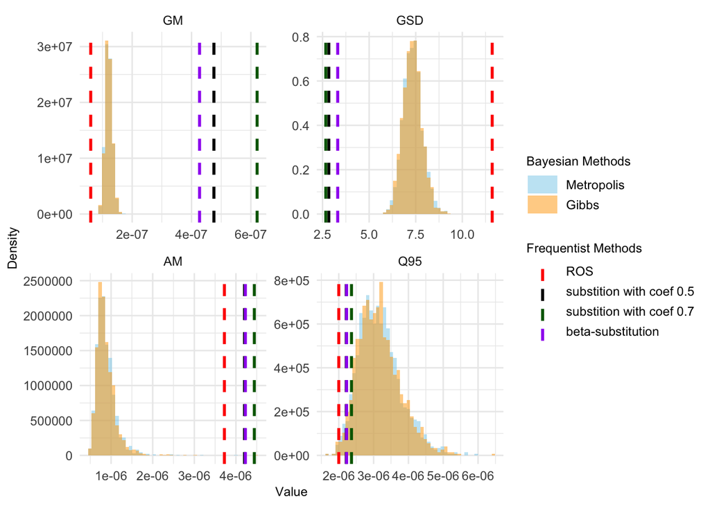

```r
# Set levels for method to control legend order
estimands1_long <- rbind(metro1_est, gibbs1_est, freq1_est) %>%
  gather(key = "Estimand", value = "Value", GM, GSD, AM, Q95) %>%
  mutate(method = factor(method, levels = c("Metropolis", "Gibbs", "ROS",
                                            "substition with coef 0.5",
                                            "substition with coef 0.7",
                                            "beta-substitution")))

# Re-define factor levels for Estimand again (safe redundancy)
estimands1_long$Estimand <- factor(estimands1_long$Estimand, levels = c("GM", "GSD", "AM", "Q95"))

# Define custom fill and line colors
fill_colors <- c("Metropolis" = "skyblue",
                 "Gibbs" = "orange")

line_colors <- c("ROS" = "red",
                 "substition with coef 0.5" = "black",
                 "substition with coef 0.7" = "darkgreen",
                 "beta-substitution" = "purple")

# Create the plot
ggplot() +
  # Metropolis histogram
  geom_histogram(data = subset(estimands1_long, method == "Metropolis"),
                 aes(x = Value, y = ..density.., fill = method),
                 color = NA, alpha = 0.5, bins = 50) +
  # Gibbs histogram
  geom_histogram(data = subset(estimands1_long, method == "Gibbs"),
                 aes(x = Value, y = ..density.., fill = method),
                 color = NA, alpha = 0.5, bins = 50) +
  # Frequentist vertical lines
  geom_vline(data = subset(estimands1_long, method %in% names(line_colors)),
             aes(xintercept = Value, color = method),
             linetype = "dashed", linewidth = 1) +
  facet_wrap(~ Estimand, scales = "free", ncol = 2) +
  scale_fill_manual(values = fill_colors, name = "Bayesian Methods") +
  scale_color_manual(values = line_colors, name = "Frequentist Methods") +
  labs(x = "Value", y = "Density") +
  theme_minimal() +
  theme(
    legend.position = "right",
    legend.box = "vertical",
    legend.spacing.y = unit(0.3, "cm"),
    legend.title = element_text(size = 9),
    legend.text = element_text(size = 9),
    strip.text = element_text(size = 9),
    axis.text = element_text(size = 9),
    axis.title = element_text(size = 9),
    legend.key.height = unit(0.5, "cm"),
    legend.key.width = unit(0.8, "cm")
  ) +
  guides(
    color = guide_legend(nrow = 4, byrow = TRUE, title.position = "top"),
    fill = guide_legend(nrow = 2, byrow = TRUE, title.position = "top")
  )
```

## 5.2 Two-element

As aforementioned, the Gibbs sampler for the two-element data did not converge well, and thus the resulting estimands are not very meaningful for comparison with other methods. However, we still present the results here to demonstrate the process. As shown, the Gibbs sampler produced very different results from the Frequentist methods, similar to what we observed for the single-element case. The only exception is for the Arithmetic Mean (AM), where the Gibbs estimate is close to the ROS estimate.

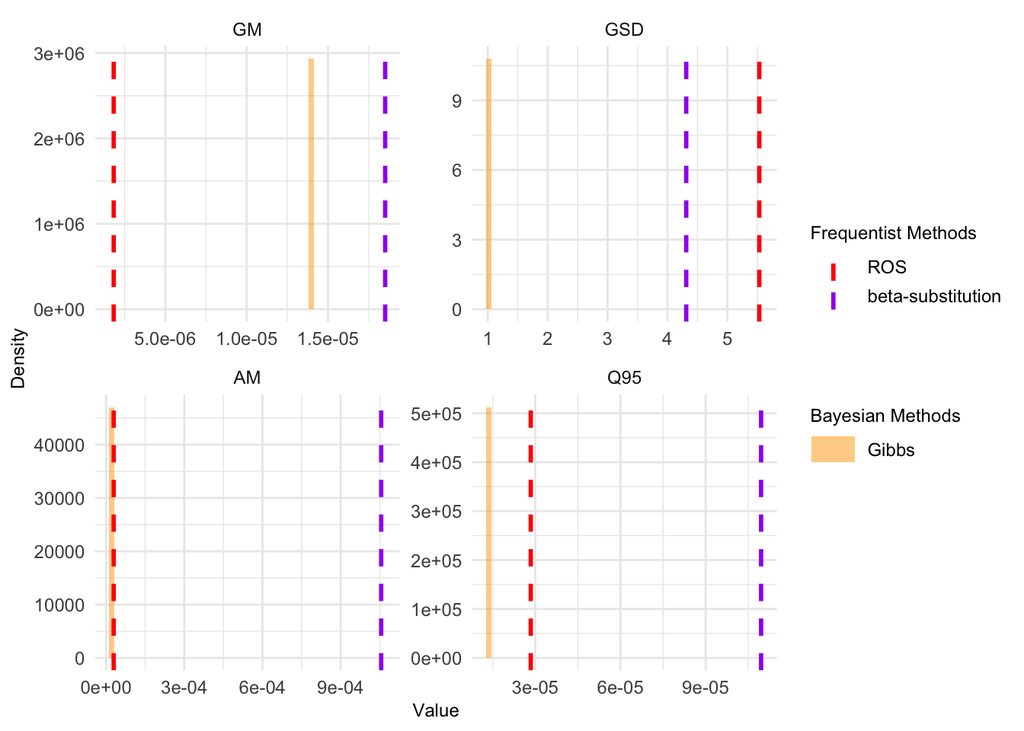

```r
# R-bind the data, excluding 'Metropolis' from the method factor levels
estimands2_long <- rbind(gibbs2_est, freq2_est) %>%
  gather(key = "Estimand", value = "Value", GM, GSD, AM, Q95) %>%
  mutate(method = factor(method, levels = c("Gibbs", "ROS",
                                            "substition with coef 0.5",
                                            "substition with coef 0.7",
                                            "beta-substitution")))
# Ensure 'Value' is numeric
estimands2_long$Value <- as.numeric(estimands2_long$Value)

# Re-define factor levels for Estimand again (safe redundancy)
estimands2_long$Estimand <- factor(estimands2_long$Estimand, levels = c("GM", "GSD", "AM", "Q95"))

# Define custom fill and line colors
fill_colors <- c("Gibbs" = "orange")  # Only coloring 'Gibbs' for now

line_colors <- c("ROS" = "red",
                 "substition with coef 0.5" = "black",
                 "substition with coef 0.7" = "darkgreen",
                 "beta-substitution" = "purple")

# Create the plot
ggplot() +
  # Gibbs histogram (Only plotting 'Gibbs')
  geom_histogram(data = subset(estimands2_long, method == "Gibbs"),
                 aes(x = Value, y = ..density.., fill = method),
                 color = NA, alpha = 0.5, bins = 50) +

  # Frequentist vertical lines (plot vertical lines for the frequentist methods)
  geom_vline(data = subset(estimands2_long, method %in% names(line_colors)),
             aes(xintercept = Value, color = method),
             linetype = "dashed", linewidth = 1) +

  facet_wrap(~ Estimand, scales = "free", ncol = 2) +

  # Custom colors for Bayesian (fill) and Frequentist (color)
  scale_fill_manual(values = fill_colors, name = "Bayesian Methods") +
  scale_color_manual(values = line_colors, name = "Frequentist Methods") +

  labs(x = "Value", y = "Density") +
  theme_minimal() +

  theme(
    legend.position = "right",
    legend.box = "vertical",
    legend.spacing.y = unit(0.3, "cm"),
    legend.title = element_text(size = 9),
    legend.text = element_text(size = 9),
    strip.text = element_text(size = 9),
    axis.text = element_text(size = 9),
    axis.title = element_text(size = 9),
    legend.key.height = unit(0.5, "cm"),
    legend.key.width = unit(0.8, "cm")
  ) +

  guides(
    color = guide_legend(nrow = 4, byrow = TRUE, title.position = "top"),
    fill = guide_legend(nrow = 2, byrow = TRUE, title.position = "top")
  )
```

# 6 Discussion and conclusion

We performed Bayesian and Frequentist methods on both single-element and two-element real datasets to estimate GM, GSD, AM, and Q95. The Bayesian methods included the Metropolis algorithm and Gibbs sampling.

For the single-element case, both Bayesian methods performed relatively well in terms of convergence. However, posterior predictive checks—particularly for the maximum and the 99.99% quantile—revealed poor model fit. The high degree of censoring in the data made it challenging to accurately estimate the target quantities. When compared with Frequentist methods, all four estimands differed considerably. The Bayesian methods yielded similar posterior distributions, situated between the ROS and substitution-based Frequentist estimates. A key advantage of the Bayesian approach is that it produces a *cloud* of point estimates reflecting posterior uncertainty, whereas Frequentist methods provide only single-point estimates. Nonetheless, due to the unknown data-generating mechanism, we cannot definitively conclude which approach yields more accurate estimates.

For the two-element case, only the Gibbs sampler was implemented. Convergence diagnostics were poor, particularly for $\mu_1$ and $\mu_2$. Trace plots showed truncation-like behavior, with each mean parameter apparently constrained in opposite directions. We hypothesize that this issue arises from using a Gibbs approximation with truncated conditional normals to simulate from the bivariate truncated normal, which was chosen for computational efficiency. The resulting posterior distributions were implausible, with extremely small standard deviations, and all estimands collapsed to nearly the same value. Because of these convergence failures, we cannot interpret the posterior as valid.

Future work will investigate the root cause of the non-convergence and near-zero posterior standard deviations. We also plan a comparative study to assess the performance of the Gibbs approximation versus exact sampling from the bivariate truncated normal distribution.

In summary, both Bayesian and Frequentist methods struggled in the presence of extreme censoring. In such contexts—especially for the two-element data, where over 95% of one variable and 92% of both variables were censored—model-based inference may be inadequate. Alternative strategies, such as data recollection or model-free approaches, may be more appropriate.

**Unresolved questions for future discussion:**

- **Detection limits:** How does the variability and clustering of detection limits (e.g., 61 distinct thresholds in the single-element data vs. 29 per element in the two-element case) impact model performance? Should models incorporate these explicitly?
- **Censoring effects:** How does censoring of extreme values (e.g., maxima) influence estimation of total concentration in highly correlated data? Which correlation assumptions are most critical?
- **Independence assumptions:** Frequentist methods treat elements independently during imputation. How does this affect estimates of joint quantities when elements are strongly correlated?
- **Thinning trade-offs:** Thinning can reduce autocorrelation but also decreases the effective sample size (ESS). Under what circumstances is thinning justified? Are alternatives like increasing iterations or using more efficient samplers preferable?

**Directions for future research:**

- **Alternative distributions:** Explore non-log-normal models (e.g., Gamma distributions) to better capture heavy-tailed behavior in the data.
- **Correlation modeling:** Improve Bayesian frameworks to more realistically capture strong inter-variable correlations in multivariate data.
- **Prior sensitivity:** Conduct thorough sensitivity analyses to evaluate how prior assumptions influence posterior inference.

# 7 Appendix

## 7.1 Adaptive proposal algorithm in Metropolis

The algorithm takes univariate left-censored data as input and returns the optimal proposal standard deviations (SDs) for $\mu$ and $\sigma$, to be used in the Random Walk Metropolis (RWM) algorithm. The goal is to achieve a target acceptance rate of 44%, which is empirically known to provide efficient mixing in univariate MCMC samplers.

The algorithm initializes $\mu$ and $\sigma$ at values close to the sample mean and standard deviation of the log-transformed observed data. This helps ensure that the sampler starts in a reasonable region of the parameter space. Proposal SDs are represented on the log scale to ensure positivity and enhance numerical stability during updates.

During the burn-in phase, for each parameter, the algorithm proposes new values using RWM and evaluates acceptance based on the posterior log-density computed by the function. The log-proposal SDs are updated at each step using the Robbins-Monro stochastic approximation:

$$\log(\text{SD}) \leftarrow \log(\text{SD}) + \gamma_0 \cdot
(\text{acceptance} - \text{target}),$$

where $\gamma_0$ is the learning rate and is the desired acceptance rate (44%). If the acceptance rate is higher than the target, the proposal SD is increased; otherwise, it is decreased.

After all burn-in iterations, the algorithm returns the final optimized proposal SDs for $\mu$ and $\sigma$, converted back from the log scale. While the acceptance rate may not exactly match the target due to finite iterations, the resulting SDs typically yield efficient mixing in subsequent MCMC runs.

# 8 Disclosure of AI use

*Lorena Coppola*

https://chatgpt.com/share/6824e885-f310-8003-b7bb-4b1e2450e720

https://chatgpt.com/share/6824ea04-2c04-8003-8582-14dce19dd955

https://chatgpt.com/share/6824eabc-fc74-8003-96fd-fee47cd4c295

*Huimin Hu*

https://chatgpt.com/share/6824f948-a37c-800d-ab3b-4aaaf6b1311a

*Pooya Sabbagh Savoojbulagh*

*Akshaan Murugesu*

https://chatgpt.com/share/6824c154-2d4c-8010-ba14-d87636ed09ef

https://chatgpt.com/share/6824c19a-3224-8003-8dec-c029bbf83809

https://chatgpt.com/share/68224d12-0500-8003-86b7-afd230251aa9

*Paul Edward Schumacher*

https://chatgpt.com/share/681ddb7d-b838-800b-a737-5b70ca503423

https://chatgpt.com/share/6824e751-2100-800b-a2c8-38f3eb5dee1f

https://chatgpt.com/share/6824e785-3174-800b-99c7-5460c3ab95db